# MATH 3190 Homework 2

Focus: Notes 4 and 5

Due February 17, 2024

Your homework should be completed in R Markdown or Quarto and Knitted to an html document. You will `turn in’ this homework by uploading to your GitHub Math_3190_Assignment repository in the Homework directory.

# Problem 1 (35 points)

### Part a (30 points)

In Homework 1, you created an **R** package related to the basketball dataset with four functions in it. Now create a shiny app that relies on some of these functions.

- Let the user enter the name of the team they want information for (in a text box), and then your app should return a table that includes their wins, losses, and winning percentage (like your function you made in Problem 2j of HW 1). Look into the `knitr::kable()` function for outputting a table that looks nice.
- Have your app show a plot for something related to that entered team.
- If the user enters a team name that is not in the dataset, give a message than the user needs to enter a valid team name, and return a list of all the teams in alphabetical order.

```r
library(hoops)
```

```r
library(ggplot2)
library(tidyverse)
library(dplyr)
library(gt)
library(shiny)
ui <- fluidPage(
  titlePanel("College Basketball Data"),
  sidebarLayout(
  sidebarPanel(
    textInput("team", "Select a Team!"),
    actionButton("submit", "Go!")
    ),

    mainPanel(
        tableOutput("teamTab"),
        plotOutput("teamPlot")
      )
    )
  )


server <- function(input, output, session){
  observeEvent(input$submit, {
    req(input$team)
    tm <- input$team
    cbbga23 <- hoops::cbbga23
    Teams <- hoops::Teams
    if (tm %in% Teams$Team){
      output$teamTab <- renderTable({
        record <- tibble(tmRec(tm))

        }, digits = 3, colnames = FALSE, rownames = FALSE)

      output$teamPlot <- renderPlot({
        ptsHist(tm)
      })
    } else {

      output$teamTab <- renderTable({
        availableTms <- sort(unique(c(cbbga23$Home, cbbga23$Away)))
        message <- paste("We don't have data for that team! Try again with one of these?",
                         paste(availableTms, collapse = ",\n", recycle0 = TRUE))
        message
      }, colnames = FALSE)
      output$team_plot <- NULL
    }

  })

}
shinyApp(ui = ui, server = server)
```

[output not shown]

Shiny applications not supported in static R Markdown documents

### Part b (5 points)

Add the shiny app to an `inst/` directory in the package you created in Problem 2l of HW 1 and create a function that can be used to call your Shiny app. Be sure to document it. You can see your `mypackage` package for how I did this with the correlation app. Update your **R** package on GitHub so I can install it and run your app.

# Problem 2 (65 points)

Now it is time to practice using SQL. First, we will need some files that are worthy of being treated as databases. For this, you will need a little more than 1 GB of hard drive space. Alternatively, you should be able to store these files on your OneDrive. Go ahead and download all of the files from this link: https://drive.google.com/drive/folders/1X1hKpTZhoCNGz30ZZeJbets8pRXs_8JQ?usp=share_link. You can also click on the “flight data” folder name at the top of the page and click “Download” to download the entire folder. While the `airports.csv` and `airlines.csv` files are quite small, the `flights.csv` is over 565 MB in size and contains the records of 5,819,079 flights in USA in 2015. These data came from the [Bureau of Transportation Statistics](https://www.transtats.bts.gov).

### Part a (5 points)

While it is probable that your computer could read in this data set in its entirety, we are going to avoid that and instead make a database that we can access using SQL. Follow the example on slides 55-57 of Notes 5 to create a `.sqlite` file that contains the tables `flights` (from `flights.csv`), `airports` (from `airports.csv`), and `airlines` (from `airlines.csv`).

```r
library(inborutils)
library(DBI)
csv_to_sqlite(csv_file = "flights.csv",
              sqlite_file = "ports.sqlite",
              table_name = "flights")

csv_to_sqlite(csv_file = "airports.csv",
              sqlite_file = "ports.sqlite",
              table_name = "airports")

csv_to_sqlite(csv_file = "airlines.csv",
              sqlite_file = "ports.sqlite",
              table_name = "airlines")
```

### Part b (2 points)

Connect to the `.sqlite` database that you created in Part a like we did on slide 52 of Notes 5. Then use the `dbListTable()` function on that connection to list all the tables in the database. There should be three tables that you added in Part a.

```r
ports <- dbConnect(RSQLite::SQLite(),
                        "ports.sqlite")
dbListTables(ports)
```

```
## [1] "airlines" "airports" "flights"
```

### Part c (1 point)

There are many different types of SQL databases: MySQL, SQLite, SQL Server, etc. We created a SQLite database in Part a. A way to see all the columns of a table in an SQLite database is with the command `PRAGMA table_info('table_name')`. Using your connection from Part b, use the `dbGetQuery()` function in an **R** code chunk to print all the column names from the `flights` table. This is useful when we have a large file that is hard to even open to see what variables are in there.

```r
DBI::dbGetQuery(ports, "PRAGMA table_info ('flights')")
```

```
##    cid                name type notnull dflt_value pk
## 1    0                YEAR REAL       0         NA  0
## 2    1               MONTH REAL       0         NA  0
## 3    2                 DAY REAL       0         NA  0
## 4    3         DAY_OF_WEEK REAL       0         NA  0
## 5    4             AIRLINE TEXT       0         NA  0
## 6    5       FLIGHT_NUMBER REAL       0         NA  0
## 7    6         TAIL_NUMBER TEXT       0         NA  0
## 8    7      ORIGIN_AIRPORT TEXT       0         NA  0
## 9    8 DESTINATION_AIRPORT TEXT       0         NA  0
## 10   9 SCHEDULED_DEPARTURE TEXT       0         NA  0
## 11  10      DEPARTURE_TIME TEXT       0         NA  0
## 12  11     DEPARTURE_DELAY REAL       0         NA  0
## 13  12            TAXI_OUT REAL       0         NA  0
## 14  13          WHEELS_OFF TEXT       0         NA  0
```

[output cut: 17 more lines]

### Part d (24 points)

Again using the `dbGetQuery()` function (one query per part) in an **R** code chunk, use SQL statements to answer the following questions. Note that distances are in miles.

1. What is the average distance of all flights in the US in 2015?

```r
dbGetQuery(ports, "SELECT AVG(DISTANCE)
                   FROM FLIGHTS
                   WHERE YEAR = 2015")
```

[output not shown]

**The average distance is 816.2604 miles.**

2. What is the minimum flight distance of all flights in the US in 2015?

```r
dbGetQuery(ports, "SELECT MIN(DISTANCE)
                   FROM FLIGHTS
                   WHERE YEAR = 2015")
```

[output not shown]

**The minimum distance was 21 miles.**

3. What is the maximum flight distance of all flights in the US in 2015?

```r
dbGetQuery(ports, "SELECT MAX(DISTANCE)
                   FROM FLIGHTS
                   WHERE YEAR = 2015")
```

[output not shown]

```r
dbGetQuery(ports, "SELECT MIN(DISTANCE),
                   ORIGIN_AIRPORT,
                   DESTINATION_AIRPORT
                   FROM FLIGHTS
                   WHERE YEAR = 2015")
```

[output not shown]

**From EWR to JFK**

5. Between what two airports did the maximum distance flight take place? The `SELECT DISTINCT` command will be useful here.

```r
dbGetQuery(ports, "SELECT MAX(DISTANCE),
                   ORIGIN_AIRPORT,
                   DESTINATION_AIRPORT
                   FROM FLIGHTS
                   WHERE YEAR = 2015")
```

[output not shown]

**From JFK to HNL**

6. You might notice that some airports are coded with numbers instead of their IATA codes. Repeat item 5, but do not include the airports that begin with a “1”.

```r
dbGetQuery(ports, "SELECT MAX(DISTANCE),
                   ORIGIN_AIRPORT,
                   DESTINATION_AIRPORT
                   FROM FLIGHTS
                   WHERE YEAR = 2015
                   AND ORIGIN_AIRPORT NOT LIKE \"1%\"
                   AND DESTINATION_AIRPORT NOT LIKE \"1%\"")
```

[output not shown]

**From JFK to HNL**

7. While you may know what these airports codes are, it would be nice if the full name of the airport was printed. The airport code information is in the `airport` table in your database in the `IATA_CODE` variable. Use the `INNER JOIN` statement to output the airport name for the two airports that have the minimum flight distance. Note that this command can take a few seconds to run.

```r
dbGetQuery(ports, " SELECT
                    flights.ORIGIN_AIRPORT,
                    flights.DISTANCE,
                    flights.DESTINATION_AIRPORT,
                    airports.AIRPORT
                    FROM flights
                    INNER JOIN airports on flights.ORIGIN_AIRPORT
                  = airports.IATA_CODE or flights.DESTINATION_AIRPORT =                     airports.IATA_CODE
                    WHERE DISTANCE = 21")
```

[output not shown]

**John F. Kennedy International and Newark Liberty International Airport** 8. Repeat item 7 with the maximum flight distances.

```r
dbGetQuery(ports, " SELECT
                    flights.ORIGIN_AIRPORT,
                    flights.DISTANCE,
                    flights.DESTINATION_AIRPORT,
                    airports.AIRPORT
                    FROM flights
                    INNER JOIN airports on flights.ORIGIN_AIRPORT
                  = airports.IATA_CODE or flights.DESTINATION_AIRPORT =                     airports.IATA_CODE
                    WHERE DISTANCE = 4983")
```

[output not shown]

**John F. Kennedy International and Honolulu International Airport**

## Part e (11 points)

Many of these queries are generating outputs that are fairly small. That is, they are easily able to be stored as variables in **R**. A couple hundred thousand rows is fine to work with since that only takes a couple MB of RAM.

1. Using the `dbGetQuery()` function again, obtain the arrival delay times and the name of the airline (by joining with the airlines table) for all the data entries that have a delay time more than 60 minutes. Save this output as a tibble in **R**.

```r
delays <- dbGetQuery(ports, "SELECT flights.ARRIVAL_DELAY,
                     airlines.AIRLINE
                     FROM flights
                     LEFT JOIN airlines ON flights.AIRLINE =
                     airlines.IATA_CODE
                     where flights.ARRIVAL_DELAY > 60

                     ")
```

2. Once you have this, make side-by-side boxplots in `ggplot()` for the arrival delay time split by the airline. This plot won’t look too great unless the y-axis is scaled. Go ahead and use the log10 scale like we did back in Lab 3. Then look up how to angle the axis labels so they do not overlap and incorporate that in your plot.

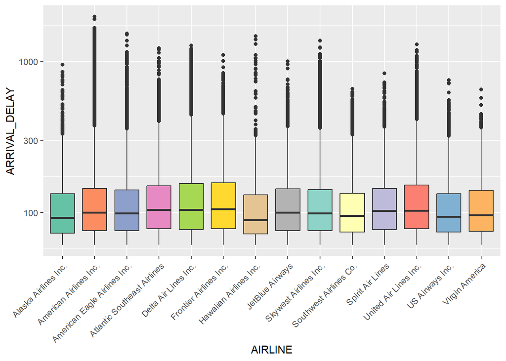

```r
library(ggplot2)
library(RColorBrewer)
colors = c(brewer.pal(name="Set2", n = 8), brewer.pal(name="Set3", n = 6))
ggplot(delays, aes(x = AIRLINE, y = ARRIVAL_DELAY, fill = AIRLINE)) +
  geom_boxplot(show.legend = FALSE) +
  scale_y_log10() +
  theme(axis.text.x = element_text(angle = 45, hjust = 1)) +
  scale_fill_manual(values = colors)
```

### Part f (10 points)

1. Now, let’s NOT use the `dbGetQuery()` function. Instead, insert an SQL code chunk for this part of the problem that selects the **average** arrival delay (for some reason, there is not a median function built in to SQL) and the airline’s full name for each airline. So, this output should only have 14 rows.

```sql
SELECT AVG(flights.ARRIVAL_DELAY) AS "AvgDelay", airlines.AIRLINE
FROM flights
LEFT JOIN airlines ON flights.AIRLINE = airlines.IATA_CODE
GROUP BY airlines.AIRLINE
```

2. Then pass this output back to **R** and create a barplot with the airlines on the x-axis and the average arrival delay on the y-axis. Again, angle the x-axis labels so they do not overlap.

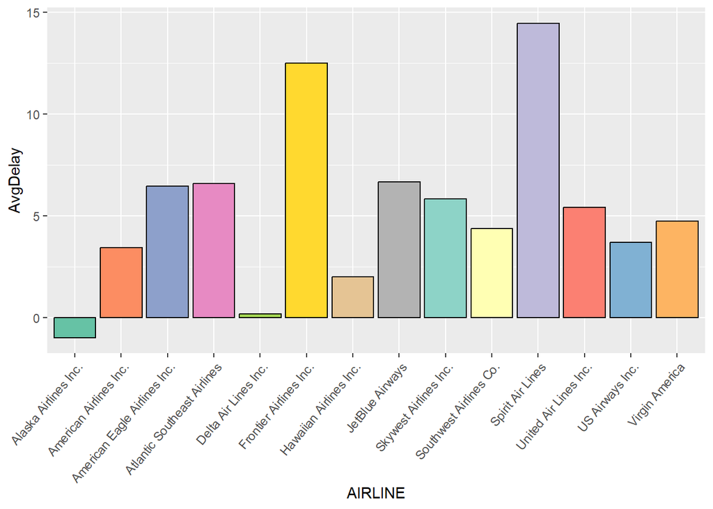

```r
ggplot(avgDelay, aes(x = AIRLINE, y = AvgDelay, fill = AIRLINE)) +
  geom_col(color = "black", show.legend = F) +
    theme(axis.text.x = element_text(angle = 50, hjust = 1)) +
    scale_fill_manual(values = colors)
```

### Part g (12 points)

1. Now let’s use the `dbplyr` add-on to the `dplyr` package to work with an SQL database directly. You may have to install the `dbplyr` package. Use the `tbl()` function to create an object you can work with directly.

```r
library(dbplyr)
flights <- tbl(ports, "flights")
airlines <- tbl(ports, "airlines")
aiports <- tbl(ports, "airports")
```

2. With that object, using **R** commands from the tidyverse, find the average and standard deviation of the elapsed time of the flights by airline and arrange it by the SD (with the largest at the top). Make sure to use the `inner_join()` function so that the name of the airline, not just its code, is given. Note that to save this object in **R**’s memory, you will need to do something like pipe it into the `collect()` function.

```r
elapsedTime <-
  flights |>
  group_by(AIRLINE) |>
  summarize(
    avg = mean(ELAPSED_TIME),
    sd = sd(ELAPSED_TIME)
  ) |>
  inner_join(airlines, by = join_by(AIRLINE == IATA_CODE)) |>
  arrange(desc(sd)) |>
  collect()
elapsedTime <- elapsedTime |>
  rename("AL" = "AIRLINE", "Average" = "avg", "SD" = "sd", "Airline" = "AIRLINE.y")
```

3. Finally, make a ggplot bar graph like the one you made in Part f, but use the standard deviation as the heights on the y-axis. Why do you suppose the airline with the largest standard deviation in elapsed time has such variable flight times?

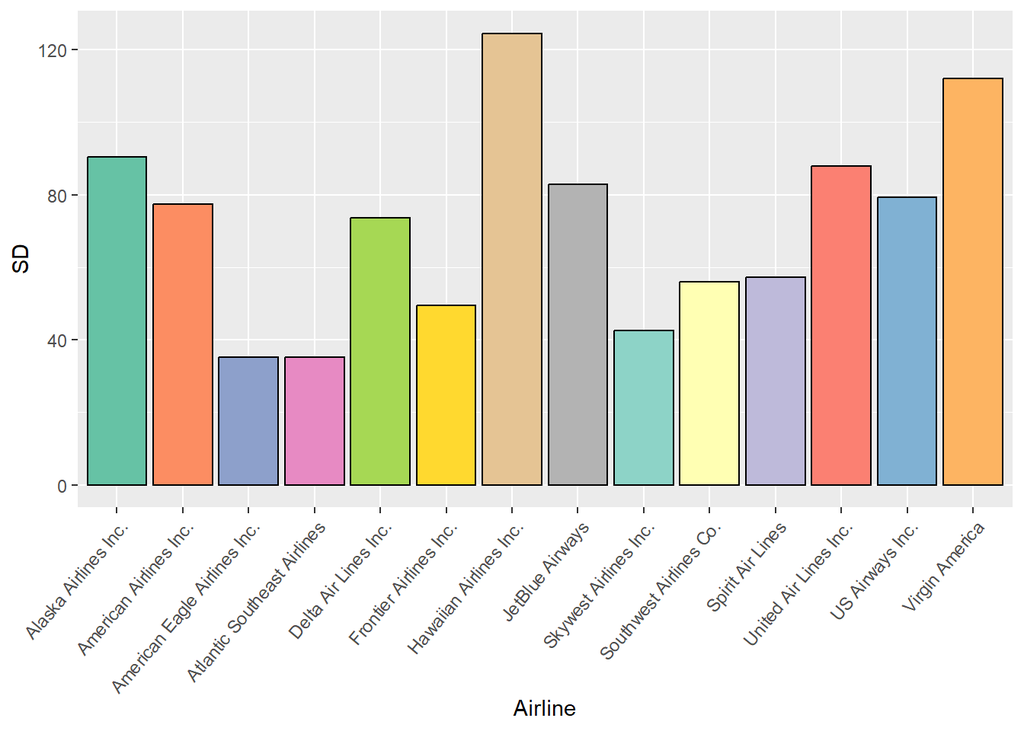

```r
ggplot(elapsedTime, aes(x = Airline, y = SD, fill = Airline)) +
  geom_col(color = "black", show.legend = F) +
    theme(axis.text.x = element_text(angle = 50, hjust = 1)) +
    scale_fill_manual(values = colors)
```

**Assuming that Hawaiian Airlines is an airline operating inside of Hawaii, they probably have such variable flight times because they’re either flying to other Hawaiian airports (super close) or airports outside of Hawaii (super far)**

Finally, when you are done with this assignment, it is good practice to close the connection to the flights database.

```r
dbDisconnect(ports)
```